# Dimensionality reduction techniques

```r
human <- read.csv("C:/Users/Admin/Documents/GitHub/IODS-project/data/human.csv", row.names = 1)
str(human)
```

```
## 'data.frame':    155 obs. of  8 variables:
##  $ second_edu_F      : num  97.4 94.3 95 95.5 87.7 96.3 80.5 95.1 100 95 ...
##  $ labour_particip_F : num  61.2 58.8 61.8 58.7 58.5 53.6 53.1 56.3 61.6 62 ...
##  $ life_expectancy   : num  81.6 82.4 83 80.2 81.6 80.9 80.9 79.1 82 81.8 ...
##  $ edu_expected      : num  17.5 20.2 15.8 18.7 17.9 16.5 18.6 16.5 15.9 19.2 ...
##  $ GNI               : int  64992 42261 56431 44025 45435 43919 39568 52947 42155 32689 ...
##  $ maternal_mortality: int  4 6 6 5 6 7 9 28 11 8 ...
##  $ adol_birthrate    : num  7.8 12.1 1.9 5.1 6.2 3.8 8.2 31 14.5 25.3 ...
##  $ repres_parliament : num  39.6 30.5 28.5 38 36.9 36.9 19.9 19.4 28.2 31.4 ...
```

The data has been combined from two datasets of the UN development program: the human development index data and the gender inequality index data. The variables included here are the following:

- Female population with at least some secondary education (second_edu_F)
- Female labour force participation rate (labour_particip_F)
- Life expectancy at birth (life_expectancy)
- Expected years of schooling (edu_expected)
- Gross national income per capita (GNI)
- Maternal mortality ratio (maternal_mortality)
- Adolescent birth rate (adol_birthrate)
- Share of seats in parliament held by women (repres_parliament)

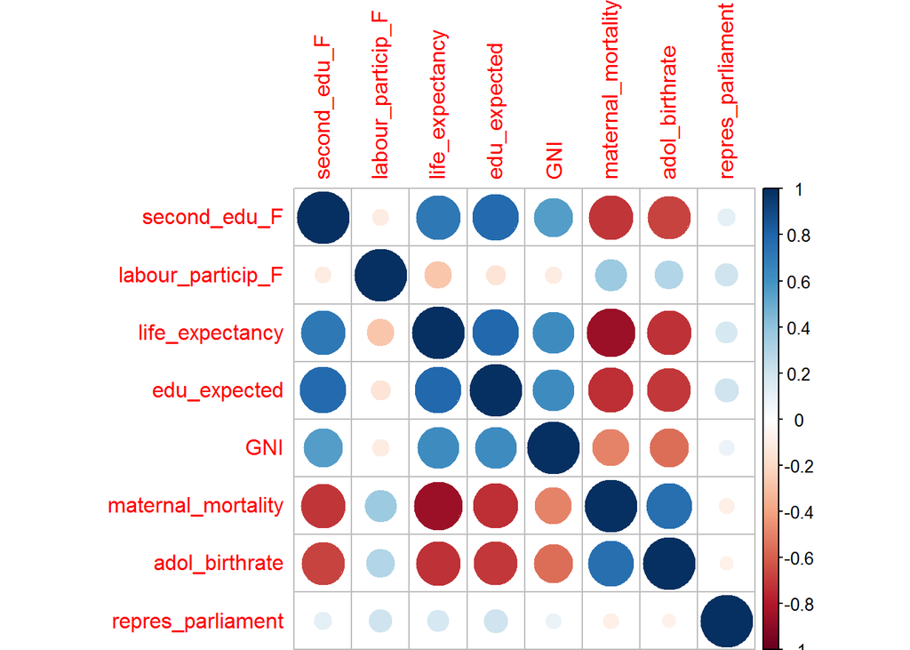

```r
library(dplyr)
library(corrplot)
cor(human) %>% corrplot()
```

```r
summary(human)
```

```
##   second_edu_F    labour_particip_F life_expectancy  edu_expected
##  Min.   :  0.90   Min.   :13.50     Min.   :49.00   Min.   : 5.40
##  1st Qu.: 27.15   1st Qu.:44.45     1st Qu.:66.30   1st Qu.:11.25
##  Median : 56.60   Median :53.50     Median :74.20   Median :13.50
##  Mean   : 55.37   Mean   :52.52     Mean   :71.65   Mean   :13.18
##  3rd Qu.: 85.15   3rd Qu.:61.90     3rd Qu.:77.25   3rd Qu.:15.20
##  Max.   :100.00   Max.   :88.10     Max.   :83.50   Max.   :20.20
##       GNI         maternal_mortality adol_birthrate   repres_parliament
##  Min.   :   581   Min.   :   1.0     Min.   :  0.60   Min.   : 0.00
##  1st Qu.:  4198   1st Qu.:  11.5     1st Qu.: 12.65   1st Qu.:12.40
##  Median : 12040   Median :  49.0     Median : 33.60   Median :19.30
##  Mean   : 17628   Mean   : 149.1     Mean   : 47.16   Mean   :20.91
##  3rd Qu.: 24512   3rd Qu.: 190.0     3rd Qu.: 71.95   3rd Qu.:27.95
##  Max.   :123124   Max.   :1100.0     Max.   :204.80   Max.   :57.50
```

As one could expect, the correlation matrix plot shows that the variables are quite correlated with each other. Intrestingly however, the share of parliamentary seats held by women and the female labour participitation are the exceptions.

Principal component analysis on the human data.

```r
pca_human <- prcomp(human)
summary(pca_human)
```

```
## Importance of components:
##                              PC1      PC2   PC3   PC4   PC5   PC6   PC7
## Standard deviation     1.854e+04 186.2835 25.97 20.07 14.32 10.63 3.721
## Proportion of Variance 9.999e-01   0.0001  0.00  0.00  0.00  0.00 0.000
## Cumulative Proportion  9.999e-01   1.0000  1.00  1.00  1.00  1.00 1.000
##                          PC8
## Standard deviation     1.428
## Proportion of Variance 0.000
## Cumulative Proportion  1.000
```

So the principal component 1 captures prety much the whole variance. Next visualising the pc’s and the observations and the original variables with a biplot.

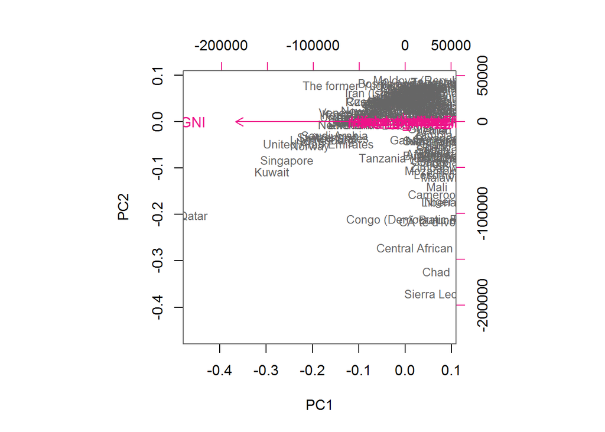

```r
biplot(pca_human, choices = 1:2, cex = c(0.8, 1), col = c("grey40", "deeppink2"))
```

From here it’s clear that the reason for PC1’s dominance lies in the distribution of the GNI variable. he analysis can be repeated with standardized variables.

```r
human_std <- scale(human)
pca_human_std <- prcomp(human_std)
summary(pca_human_std)
```

```
## Importance of components:
##                           PC1    PC2     PC3     PC4     PC5    PC6
## Standard deviation     2.1360 1.1171 0.87671 0.72027 0.55309 0.5299
## Proportion of Variance 0.5703 0.1560 0.09608 0.06485 0.03824 0.0351
## Cumulative Proportion  0.5703 0.7263 0.82235 0.88720 0.92544 0.9605
##                            PC7     PC8
## Standard deviation     0.44935 0.33728
## Proportion of Variance 0.02524 0.01422
## Cumulative Proportion  0.98578 1.00000
```

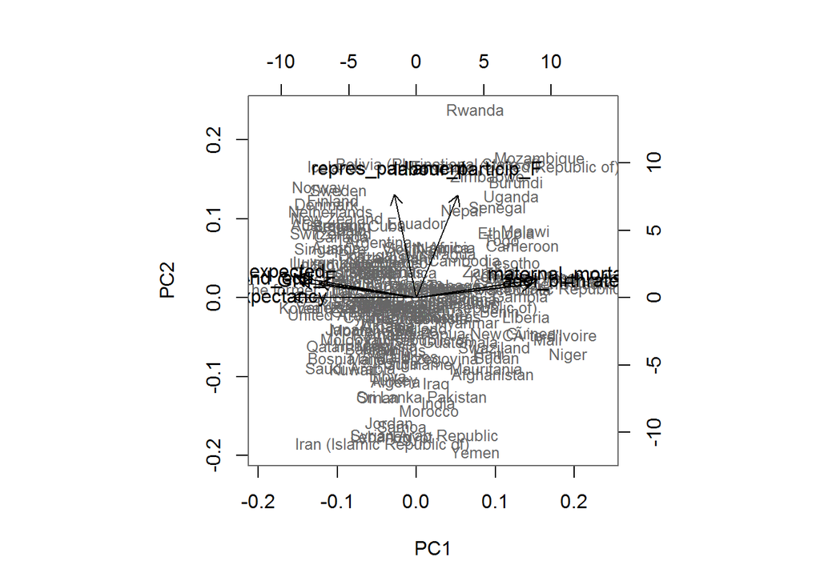

```r
biplot(pca_human_std, choices = 1:2, cex = c(0.8, 1), col = c("grey40", "black"))
```

Now both dimensions seem to capture something more meaningful than just the GNI. My interpretation is that PC1 is about the level of economic development and material standard of living, which translates to the overall health of the population. Countries with higher GNI and life expectancy group to the left and developing countries with higher mortality and birth rates group to the rights. These variables were all correlated as seen in the correlation matrix.

PC2 to my mind tells about the inequality between genders. The original variables associated with it are the share of parliamentary seats held by women and the labour participitation of women. You can see how nordic countries are quite high up on the y-axis with some developing countries there as well. Low on the y-axis, we find for example countries that are economically more developed compared to many Sub-Saharan countries but have more gender inequality. These are located in the Middle East and its surroundings.

Next it is time for Multiple Correspondence Analysis on the tea consumption questionnaire data from FactoMineR package.

```r
library(FactoMineR)
data("tea")
str(tea)
```

```
## 'data.frame':    300 obs. of  36 variables:
##  $ breakfast       : Factor w/ 2 levels "breakfast","Not.breakfast": 1 1 2 2 1 2 1 2 1 1 ...
##  $ tea.time        : Factor w/ 2 levels "Not.tea time",..: 1 1 2 1 1 1 2 2 2 1 ...
##  $ evening         : Factor w/ 2 levels "evening","Not.evening": 2 2 1 2 1 2 2 1 2 1 ...
##  $ lunch           : Factor w/ 2 levels "lunch","Not.lunch": 2 2 2 2 2 2 2 2 2 2 ...
##  $ dinner          : Factor w/ 2 levels "dinner","Not.dinner": 2 2 1 1 2 1 2 2 2 2 ...
##  $ always          : Factor w/ 2 levels "always","Not.always": 2 2 2 2 1 2 2 2 2 2 ...
##  $ home            : Factor w/ 2 levels "home","Not.home": 1 1 1 1 1 1 1 1 1 1 ...
##  $ work            : Factor w/ 2 levels "Not.work","work": 1 1 2 1 1 1 1 1 1 1 ...
##  $ tearoom         : Factor w/ 2 levels "Not.tearoom",..: 1 1 1 1 1 1 1 1 1 2 ...
##  $ friends         : Factor w/ 2 levels "friends","Not.friends": 2 2 1 2 2 2 1 2 2 2 ...
##  $ resto           : Factor w/ 2 levels "Not.resto","resto": 1 1 2 1 1 1 1 1 1 1 ...
##  $ pub             : Factor w/ 2 levels "Not.pub","pub": 1 1 1 1 1 1 1 1 1 1 ...
##  $ Tea             : Factor w/ 3 levels "black","Earl Grey",..: 1 1 2 2 2 2 2 1 2 1 ...
##  $ How             : Factor w/ 4 levels "alone","lemon",..: 1 3 1 1 1 1 1 3 3 1 ...
```

[output cut: 22 more lines]

Choosing some variables of intrest.

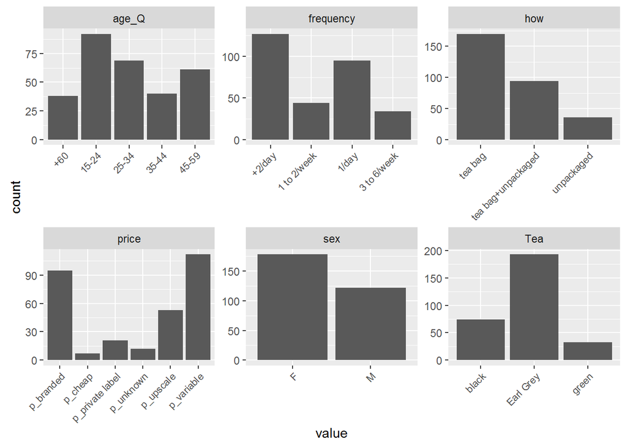

```r
library(ggplot2)
library(tidyr)
keep <- c("age_Q", "sex", "how", "Tea", "price", "frequency")
tea_time <- select(tea, one_of(keep))
gather(tea_time) %>% ggplot(aes(value)) + facet_wrap("key", scales = "free") + geom_bar() + theme(axis.text.x = element_text(angle = 45, hjust = 1, size = 8))
```

```r
mca <- MCA(tea_time, graph = FALSE)
summary(mca)
```

```
##
## Call:
## MCA(X = tea_time, graph = FALSE)
##
##
## Eigenvalues
##                        Dim.1   Dim.2   Dim.3   Dim.4   Dim.5   Dim.6
## Variance               0.299   0.243   0.230   0.207   0.186   0.178
## % of var.             10.568   8.592   8.113   7.298   6.569   6.267
## Cumulative % of var.  10.568  19.160  27.273  34.571  41.140  47.407
##                        Dim.7   Dim.8   Dim.9  Dim.10  Dim.11  Dim.12
## Variance               0.177   0.171   0.162   0.148   0.146   0.141
## % of var.              6.234   6.043   5.719   5.237   5.161   4.991
## Cumulative % of var.  53.641  59.684  65.403  70.640  75.801  80.792
##                       Dim.13  Dim.14  Dim.15  Dim.16  Dim.17
## Variance               0.131   0.124   0.112   0.099   0.079
## % of var.              4.626   4.372   3.941   3.484   2.785
## Cumulative % of var.  85.418  89.790  93.731  97.215 100.000
##
## Individuals (the 10 first)
##                       Dim.1    ctr   cos2    Dim.2    ctr   cos2    Dim.3
## 1                  |  0.086  0.008  0.001 |  1.127  1.738  0.201 |  0.270
## 2                  |  0.042  0.002  0.001 |  0.049  0.003  0.001 |  0.361
## 3                  | -0.240  0.064  0.039 | -0.417  0.239  0.117 |  0.165
## 4                  | -0.532  0.316  0.192 |  0.331  0.150  0.074 | -0.240
## 5                  | -0.059  0.004  0.002 | -0.008  0.000  0.000 | -0.036
## 6                  | -0.620  0.428  0.113 |  0.765  0.802  0.172 |  0.193
## 7                  |  0.009  0.000  0.000 |  0.063  0.005  0.001 | -0.300
## 8                  |  0.160  0.028  0.008 | -0.130  0.023  0.005 |  0.176
## 9                  |  0.590  0.387  0.125 | -0.303  0.126  0.033 | -0.443
## 10                 |  1.001  1.116  0.313 | -0.334  0.153  0.035 | -0.200
##                       ctr   cos2
## 1                   0.105  0.012 |
## 2                   0.189  0.064 |
## 3                   0.039  0.018 |
## 4                   0.084  0.039 |
## 5                   0.002  0.001 |
## 6                   0.054  0.011 |
## 7                   0.131  0.029 |
## 8                   0.045  0.010 |
```

[output cut: 20 more lines]

```
## +60                  0.009  -1.679 |   0.947   8.241   0.130   6.238 |
## F                    0.355 -10.296 |   0.234   2.363   0.080   4.895 |
## M                    0.355  10.296 |  -0.342   3.447   0.080  -4.895 |
## tea bag              0.153   6.771 |   0.448   8.258   0.263   8.865 |
## tea bag+unpackaged   0.190  -7.536 |  -0.810  14.887   0.299  -9.456 |
## unpackaged           0.001   0.432 |  -0.003   0.000   0.000  -0.021 |
##
## Categorical variables (eta2)
##                      Dim.1 Dim.2 Dim.3
## age_Q              | 0.366 0.131 0.505 |
## sex                | 0.085 0.355 0.080 |
## how                | 0.452 0.197 0.319 |
## Tea                | 0.360 0.059 0.088 |
## price              | 0.492 0.277 0.381 |
## frequency          | 0.041 0.441 0.006 |
```

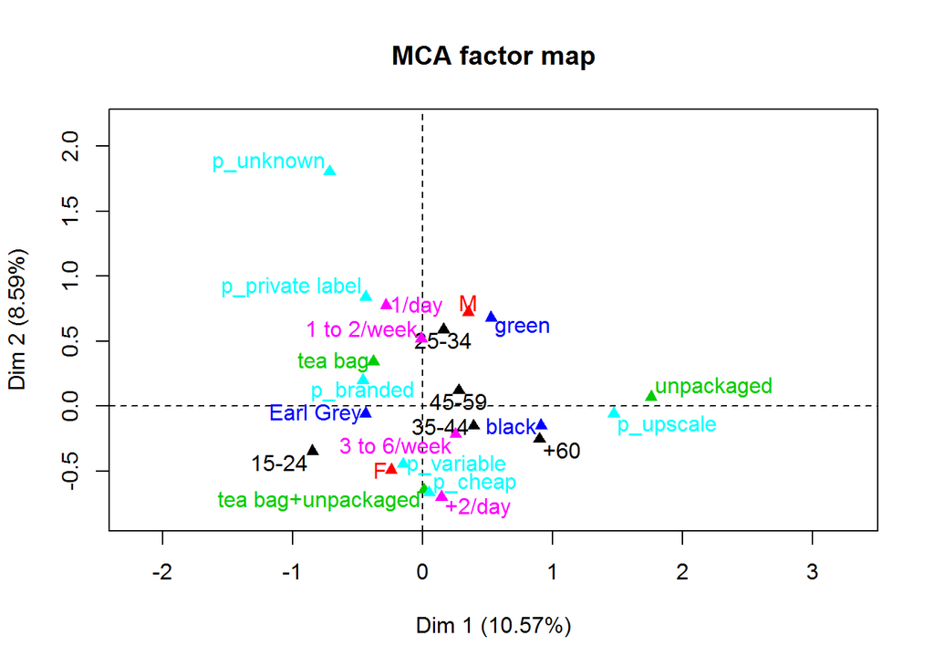

```r
plot(mca, invisible=c("ind"), habillage = "quali")
```

I would say this analysis doesn’t have much to offer as the only variable that really stands out from the rest is “unknown price”. The weakness of the analysis is apparent in the fact that the first two dimensions explain so little of the cumulative variance.